# PCA_SNE

### Principal Component Analysis: Education Data

```python
#Principal Component Analysis using education data set.

#import libraries
import pandas as pd
import numpy as np
import matplotlib.pyplot as plt
import seaborn as sns
%matplotlib inline

#to scale using z-score
from sklearn.preprocessing import StandardScaler

#import PCA and SNE
from sklearn.decomposition import PCA
from sklearn.manifold import TSNE

#suppress warnings
import warnings
warnings.filterwarnings('ignore')

#load the data set
data = pd.read_csv('./datasets/Education.csv')

#copy
data = data.copy()

data.head()
```

|  | Names | Apps | Accept | Enroll | Top10perc | Top25perc | F_Undergrad | P_Undergrad | Outstate | Room_Board | Books | Personal | PhD | Terminal | S_F_Ratio | perc_alumni | Expend | Grad_Rate |
| --- | --- | --- | --- | --- | --- | --- | --- | --- | --- | --- | --- | --- | --- | --- | --- | --- | --- | --- |
| 0 | Abilene Christian University | 1660 | 1232 | 721 | 23 | 52 | 2885 | 537 | 7440 | 3300 | 450 | 2200 | 70 | 78 | 18.1 | 12 | 7041 | 60 |
| 1 | Adelphi University | 2186 | 1924 | 512 | 16 | 29 | 2683 | 1227 | 12280 | 6450 | 750 | 1500 | 29 | 30 | 12.2 | 16 | 10527 | 56 |
| 2 | Adrian College | 1428 | 1097 | 336 | 22 | 50 | 1036 | 99 | 11250 | 3750 | 400 | 1165 | 53 | 66 | 12.9 | 30 | 8735 | 54 |
| 3 | Agnes Scott College | 417 | 349 | 137 | 60 | 89 | 510 | 63 | 12960 | 5450 | 450 | 875 | 92 | 97 | 7.7 | 37 | 19016 | 59 |
| 4 | Alaska Pacific University | 193 | 146 | 55 | 16 | 44 | 249 | 869 | 7560 | 4120 | 800 | 1500 | 76 | 72 | 11.9 | 2 | 10922 | 15 |

```python
#check info
data.info()
```

```
<class 'pandas.core.frame.DataFrame'>
RangeIndex: 777 entries, 0 to 776
Data columns (total 18 columns):
 #   Column       Non-Null Count  Dtype
---  ------       --------------  -----
 0   Names        777 non-null    object
 1   Apps         777 non-null    int64
 2   Accept       777 non-null    int64
 3   Enroll       777 non-null    int64
 4   Top10perc    777 non-null    int64
 5   Top25perc    777 non-null    int64
 6   F_Undergrad  777 non-null    int64
 7   P_Undergrad  777 non-null    int64
 8   Outstate     777 non-null    int64
 9   Room_Board   777 non-null    int64
 10  Books        777 non-null    int64
 11  Personal     777 non-null    int64
 12  PhD          777 non-null    int64
 13  Terminal     777 non-null    int64
 14  S_F_Ratio    777 non-null    float64
 15  perc_alumni  777 non-null    int64
 16  Expend       777 non-null    int64
 17  Grad_Rate    777 non-null    int64
dtypes: float64(1), int64(16), object(1)
memory usage: 109.4+ KB
```

#### Observations

1. There are 777 rows and 18 columns in the dataset
2. All the columns are numerical except Names column which is nominal
3. There are no missing values in the dataset

```python
#Data Preprocessing and Exploratory Data Analysis

#check the college names
data.Names
```

```
0        Abilene Christian University
1                  Adelphi University
2                      Adrian College
3                 Agnes Scott College
4           Alaska Pacific University
                    ...
772           Worcester State College
773                 Xavier University
774    Xavier University of Louisiana
775                   Yale University
776      York College of Pennsylvania
Name: Names, Length: 777, dtype: object
```

```python
#check if the college names are unique
data.Names.nunique()
```

```
777
```

#### Observations

1. All college names are unique so it won't add value to our analysis.
2. We need to drop the names column

```python
#dropping the names column
data.drop(columns= "Names", inplace=True)
```

```python
# Summary statistics
data.describe().T
```

|  | count | mean | std | min | 25% | 50% | 75% | max |
| --- | --- | --- | --- | --- | --- | --- | --- | --- |
| Apps | 777.0 | 3001.638353 | 3870.201484 | 81.0 | 776.0 | 1558.0 | 3624.0 | 48094.0 |
| Accept | 777.0 | 2018.804376 | 2451.113971 | 72.0 | 604.0 | 1110.0 | 2424.0 | 26330.0 |
| Enroll | 777.0 | 779.972973 | 929.176190 | 35.0 | 242.0 | 434.0 | 902.0 | 6392.0 |
| Top10perc | 777.0 | 27.558559 | 17.640364 | 1.0 | 15.0 | 23.0 | 35.0 | 96.0 |
| Top25perc | 777.0 | 55.796654 | 19.804778 | 9.0 | 41.0 | 54.0 | 69.0 | 100.0 |
| F_Undergrad | 777.0 | 3699.907336 | 4850.420531 | 139.0 | 992.0 | 1707.0 | 4005.0 | 31643.0 |
| P_Undergrad | 777.0 | 855.298584 | 1522.431887 | 1.0 | 95.0 | 353.0 | 967.0 | 21836.0 |
| Outstate | 777.0 | 10440.669241 | 4023.016484 | 2340.0 | 7320.0 | 9990.0 | 12925.0 | 21700.0 |
| Room_Board | 777.0 | 4357.526384 | 1096.696416 | 1780.0 | 3597.0 | 4200.0 | 5050.0 | 8124.0 |
| Books | 777.0 | 549.380952 | 165.105360 | 96.0 | 470.0 | 500.0 | 600.0 | 2340.0 |
| Personal | 777.0 | 1340.642214 | 677.071454 | 250.0 | 850.0 | 1200.0 | 1700.0 | 6800.0 |
| PhD | 777.0 | 72.660232 | 16.328155 | 8.0 | 62.0 | 75.0 | 85.0 | 103.0 |
| Terminal | 777.0 | 79.702703 | 14.722359 | 24.0 | 71.0 | 82.0 | 92.0 | 100.0 |
| S_F_Ratio | 777.0 | 14.089704 | 3.958349 | 2.5 | 11.5 | 13.6 | 16.5 | 39.8 |
| perc_alumni | 777.0 | 22.743887 | 12.391801 | 0.0 | 13.0 | 21.0 | 31.0 | 64.0 |
| Expend | 777.0 | 9660.171171 | 5221.768440 | 3186.0 | 6751.0 | 8377.0 | 10830.0 | 56233.0 |
| Grad_Rate | 777.0 | 65.463320 | 17.177710 | 10.0 | 53.0 | 65.0 | 78.0 | 118.0 |

#### Observations

1. On an average, there are 3000 applications received in the US universities in which over 2000 applications are accepted and 780 new students are enrolled.
2. The standard deviation is very high for variables apps, accept, and enrolled.
3. The average expenses for room, books, and personal are 4357, 549, and 1340 respectively.
4. The average fulltime undergrad students are 3699 which is higher than the average part time undergrad students.
5. PhD and Grad Rate have maximum values greater than 100 which is unrealistic.

```python
#Check the PhD and Grad outlier data
data[(data.PhD > 100) | (data.Grad_Rate > 100)]
```

|  | Apps | Accept | Enroll | Top10perc | Top25perc | F_Undergrad | P_Undergrad | Outstate | Room_Board | Books | Personal | PhD | Terminal | S_F_Ratio | perc_alumni | Expend | Grad_Rate |
| --- | --- | --- | --- | --- | --- | --- | --- | --- | --- | --- | --- | --- | --- | --- | --- | --- | --- |
| 95 | 3847 | 3433 | 527 | 9 | 35 | 1010 | 12 | 9384 | 4840 | 600 | 500 | 22 | 47 | 14.3 | 20 | 7697 | 118 |
| 582 | 529 | 481 | 243 | 22 | 47 | 1206 | 134 | 4860 | 3122 | 600 | 650 | 103 | 88 | 17.4 | 16 | 6415 | 43 |

#### Observations

1. One such observation for each variable
2. We need to set the maximum cap value = 100 to these variables

```python
data.loc[582,'PhD'] = 100
data.loc[95, 'Grad_Rate'] = 100
```

```python
pd.get_option("display.max_rows")
pd.set_option("display.max_rows",20)

#check
data.PhD > 100
```

```
0      False
1      False
2      False
3      False
4      False
       ...
772    False
773    False
774    False
775    False
776    False
Name: PhD, Length: 777, dtype: bool
```

```
Apps
Skew : 3.72
```

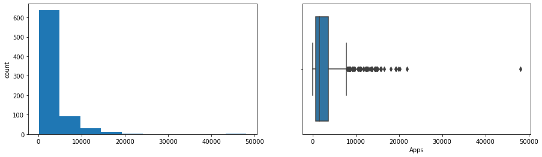

```
Accept
Skew : 3.42
```

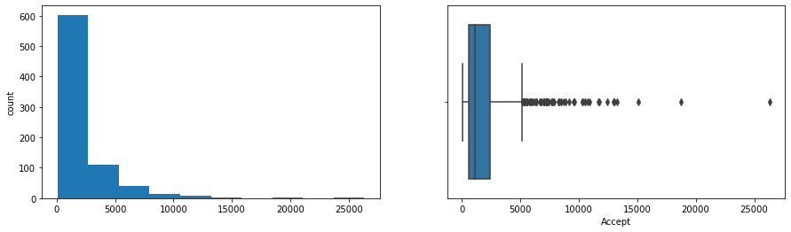

```
Enroll
Skew : 2.69
```

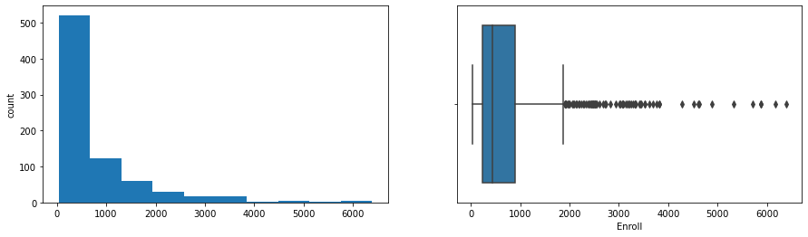

```
Top10perc
Skew : 1.41
```

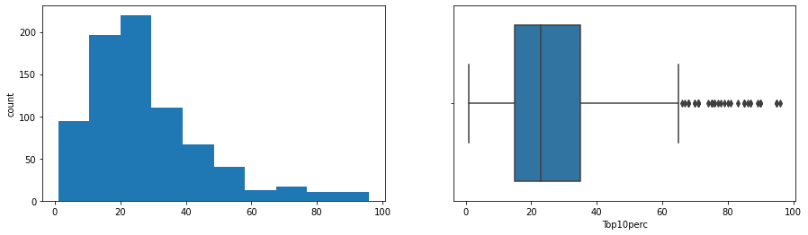

```
Top25perc
Skew : 0.26
```

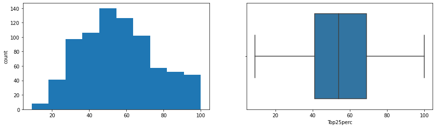

```
F_Undergrad
Skew : 2.61
```

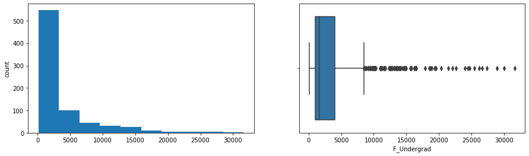

```
P_Undergrad
Skew : 5.69
```

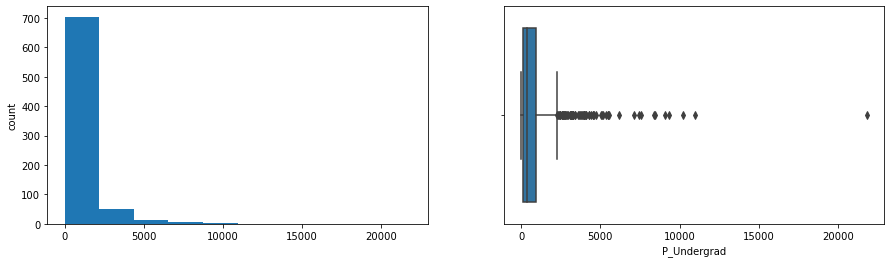

```
Outstate
Skew : 0.51
```

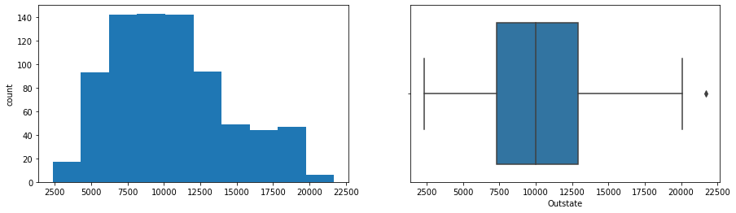

```
Room_Board
Skew : 0.48
```

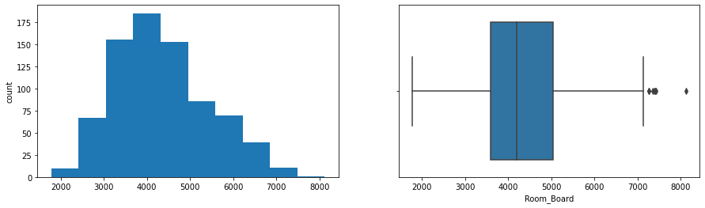

```
Books
Skew : 3.49
```

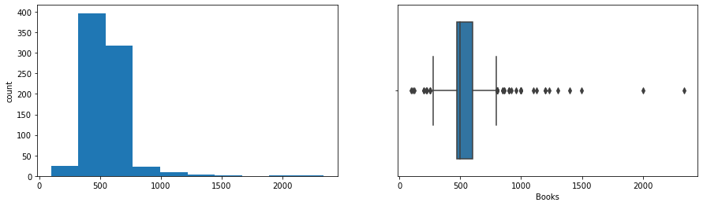

```
Personal
Skew : 1.74
```

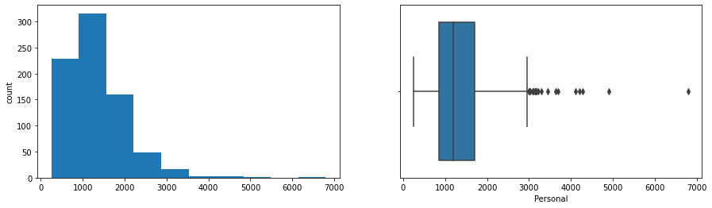

```
PhD
Skew : -0.77
```

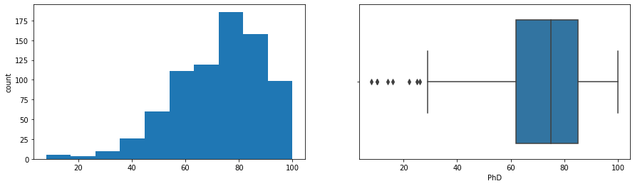

```
Terminal
Skew : -0.82
```

[5 more figures not shown]

```python
#check the distribution and outliers for each column
cont_cols = list(data.columns)

for col in cont_cols:
    print(col)

    print('Skew :', round(data[col].skew(),2))

    plt.figure(figsize = (15,4))
    plt.subplot(1,2,1)
    data[col].hist(bins=10, grid= False)
    plt.ylabel('count')
    plt.subplot(1,2,2)
    sns.boxplot(x= data[col])

    plt.show()
```

#### Observations

1. The distribution plots show Apps, Enroll, Top10perc, F_undergrad, P_undergrad, Books, Personal, and Expend variables are highly right skewed. All these variables have outliers.
2. Top25Percent is the only variable without outliers.
3. Outstate, Room_Board, S_F_ratio, and perc_alumni is moderately right skewed.
4. PhD and Terminal are moderately left skewed.

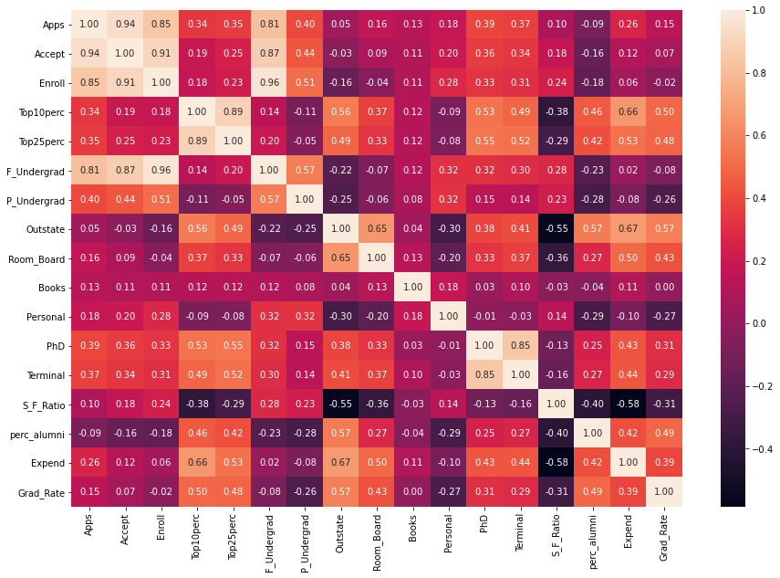

```python
#Now let's see the correlation among variables
plt.figure(figsize=(15,10))

sns.heatmap(data.corr(),annot=True, fmt='0.2f')
plt.show()
```

#### Observations

There is a high positive correlation among the following variables:

1. Apps and Accept
2. Apps and Enroll
3. Apps and F_undergrad
4. Accept and Enroll
5. Accept and F_undergrad
6. Enroll and F_undergrad
7. Top10perc and Top25percent
8. PhD and Terminal

```python
#scaling the data
scaler = StandardScaler()
data_scaled = pd.DataFrame(scaler.fit_transform(data),columns=data.columns)
```

```python
data_scaled.head()
```

|  | Apps | Accept | Enroll | Top10perc | Top25perc | F_Undergrad | P_Undergrad | Outstate | Room_Board | Books | Personal | PhD | Terminal | S_F_Ratio | perc_alumni | Expend | Grad_Rate |
| --- | --- | --- | --- | --- | --- | --- | --- | --- | --- | --- | --- | --- | --- | --- | --- | --- | --- |
| 0 | -0.346882 | -0.321205 | -0.063509 | -0.258583 | -0.191827 | -0.168116 | -0.209207 | -0.746356 | -0.964905 | -0.602312 | 1.270045 | -0.162859 | -0.115729 | 1.013776 | -0.867574 | -0.501910 | -0.317993 |
| 1 | -0.210884 | -0.038703 | -0.288584 | -0.655656 | -1.353911 | -0.209788 | 0.244307 | 0.457496 | 1.909208 | 1.215880 | 0.235515 | -2.676529 | -3.378176 | -0.477704 | -0.544572 | 0.166110 | -0.551805 |
| 2 | -0.406866 | -0.376318 | -0.478121 | -0.315307 | -0.292878 | -0.549565 | -0.497090 | 0.201305 | -0.554317 | -0.905344 | -0.259582 | -1.205112 | -0.931341 | -0.300749 | 0.585935 | -0.177290 | -0.668710 |
| 3 | -0.668261 | -0.681682 | -0.692427 | 1.840231 | 1.677612 | -0.658079 | -0.520752 | 0.626633 | 0.996791 | -0.602312 | -0.688173 | 1.185939 | 1.175657 | -1.615274 | 1.151188 | 1.792851 | -0.376446 |
| 4 | -0.726176 | -0.764555 | -0.780735 | -0.655656 | -0.596031 | -0.711924 | 0.009005 | -0.716508 | -0.216723 | 1.518912 | 0.235515 | 0.204995 | -0.523535 | -0.553542 | -1.675079 | 0.241803 | -2.948375 |

```python
#Principal Component Analysis

#defining number of principal components to generate
n = data_scaled.shape[1]

#finding principal components for the data
pca = PCA(n_components=n, random_state=1)

data_pca1 = pd.DataFrame(pca.fit_transform(data_scaled))

#the percentage of variance explained by each principal component
exp_var = pca.explained_variance_ratio_
```

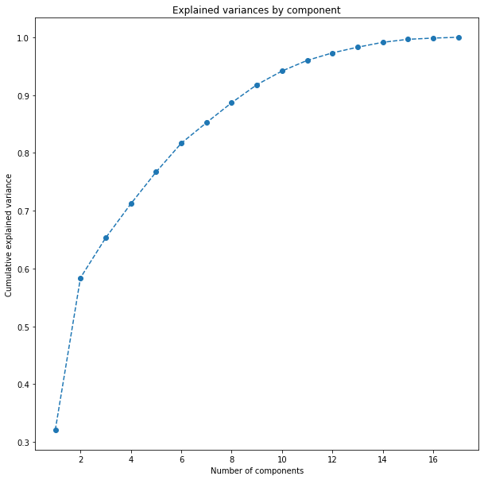

```python
#plotting cumulative variance by principal components
plt.figure(figsize=(10,10))

plt.plot(range(1,18),pca.explained_variance_ratio_.cumsum(),marker='o',linestyle='--')

plt.title("Explained variances by component")
plt.xlabel("Number of components")
plt.ylabel("Cumulative explained variance")

plt.show()
```

```python
#finding the least number of components that can explain more than 70% variance
sum = 0


for ix, i in enumerate(exp_var):

    sum = sum+i

    if(sum>0.70):

        print("Number of PCs that explain at least 70% variance:", ix+1)
        break
```

```
Number of PCs that explain at least 70% variance: 4
```

#### Observations

1. As we can see, we reduced the number of features from 17 to 4 principal components. The first four principal components explain appropriately 70% of the original value.
2. So that is about 76% reduction in the dimensionality of the dataset with only a loss of 30% in variance

Let's look at these principal components as a linear combination of the original features

```python
pc_comps = ['PC1','PC2','PC3','PC4']

data_pca = pd.DataFrame(np.round(pca.components_[:4,:],2), index = pc_comps, columns=data_scaled.columns)

data_pca.T
```

|  | PC1 | PC2 | PC3 | PC4 |
| --- | --- | --- | --- | --- |
| Apps | 0.25 | 0.33 | -0.06 | 0.28 |
| Accept | 0.21 | 0.37 | -0.10 | 0.27 |
| Enroll | 0.18 | 0.40 | -0.08 | 0.16 |
| Top10perc | 0.35 | -0.08 | 0.03 | -0.05 |
| Top25perc | 0.34 | -0.04 | -0.02 | -0.11 |
| F_Undergrad | 0.15 | 0.42 | -0.06 | 0.10 |
| P_Undergrad | 0.03 | 0.32 | 0.14 | -0.16 |
| Outstate | 0.29 | -0.25 | 0.05 | 0.13 |
| Room_Board | 0.25 | -0.14 | 0.15 | 0.19 |
| Books | 0.06 | 0.06 | 0.68 | 0.08 |
| Personal | -0.04 | 0.22 | 0.50 | -0.24 |
| PhD | 0.32 | 0.06 | -0.13 | -0.53 |
| Terminal | 0.32 | 0.05 | -0.07 | -0.52 |
| S_F_Ratio | -0.18 | 0.25 | -0.29 | -0.16 |
| perc_alumni | 0.21 | -0.25 | -0.15 | 0.02 |
| Expend | 0.32 | -0.13 | 0.23 | 0.08 |
| Grad_Rate | 0.25 | -0.17 | -0.21 | 0.26 |

#### Observation

1. Each principal component is a linear combination of the original features
2. The first two principal components pick up around 58% of the variability in the data, which is a considerable amount.

```python
def color_high(val):

    if val < -0.25:
        return 'background: pink'
    elif val > 0.25:
        return 'background: skyblue'

data_pca.T.style.applymap(color_high)
```

|  | PC1 | PC2 | PC3 | PC4 |
| --- | --- | --- | --- | --- |
| Apps | 0.250000 | 0.330000 | -0.060000 | 0.280000 |
| Accept | 0.210000 | 0.370000 | -0.100000 | 0.270000 |
| Enroll | 0.180000 | 0.400000 | -0.080000 | 0.160000 |
| Top10perc | 0.350000 | -0.080000 | 0.030000 | -0.050000 |
| Top25perc | 0.340000 | -0.040000 | -0.020000 | -0.110000 |
| F_Undergrad | 0.150000 | 0.420000 | -0.060000 | 0.100000 |
| P_Undergrad | 0.030000 | 0.320000 | 0.140000 | -0.160000 |
| Outstate | 0.290000 | -0.250000 | 0.050000 | 0.130000 |
| Room_Board | 0.250000 | -0.140000 | 0.150000 | 0.190000 |
| Books | 0.060000 | 0.060000 | 0.680000 | 0.080000 |
| Personal | -0.040000 | 0.220000 | 0.500000 | -0.240000 |
| PhD | 0.320000 | 0.060000 | -0.130000 | -0.530000 |
| Terminal | 0.320000 | 0.050000 | -0.070000 | -0.520000 |
| S_F_Ratio | -0.180000 | 0.250000 | -0.290000 | -0.160000 |
| perc_alumni | 0.210000 | -0.250000 | -0.150000 | 0.020000 |
| Expend | 0.320000 | -0.130000 | 0.230000 | 0.080000 |
| Grad_Rate | 0.250000 | -0.170000 | -0.210000 | 0.260000 |

#### Observations

1. The first principal component, PC1 seems to be related to high values of student scores top10perc, top25perc, number of outstate students, the faculty education level, and instructional expenditure per student. The first principal component seems to capture the generally define premier colleges with a high quality of students entering them, and more accomplished faculty teaching there. The students entering these colleges also appear to be financially well-off.
2. The second principal component, PC2 seems to be related to high values of number of applications received, accepted, and enrolled, and the number of full-time and part-time undergrad students. The second principal component seems to capture attributes that generally define non-premier colleges that are comparatively easier to get admissions into.
3. The third principal component seems to be related to financial aspects i.e. personal spending and cost of books for individual students. It is also associated with low values of student faculty ratio.
4. The fourth principal component seems to capture attributes that define colleges which lack highly educated faculty PhD and terminal and are comparatively easier to graduate from.

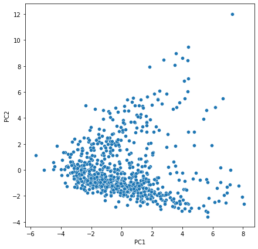

```python
# We can visualize the data into 2 dimensions
plt.figure(figsize=(7,7))

sns.scatterplot(x=data_pca1[0], y = data_pca1[1])

plt.xlabel("PC1")
plt.ylabel("PC2")

plt.show()
```

```python
# t-sne let's try to visualize the data using t-SNE by reducing the number of dimensions to 2 and 3

#fitting the t-SNE with number of components equal to 2
tsne = TSNE(n_components = 2, random_state = 1)

data_tsne = tsne.fit_transform(data_scaled)
```

```python
# converting the embeddings to a dataframe
data_tsne = pd.DataFrame(data_tsne, columns = ['X1','X2'])
```

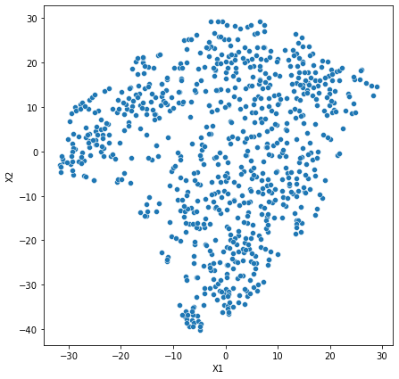

```python
#scatter plot for two components
plt.figure(figsize = (7,7))

sns.scatterplot(x = 'X1', y = 'X2', data = data_tsne)

plt.show()
```

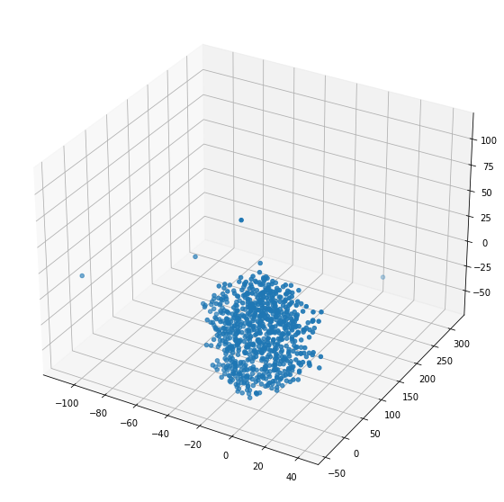

```python
#visualization in 3D
#fitting tsne with number of components equal to 3
tsne = TSNE(n_components = 3, random_state = 1)

data_tsne = tsne.fit_transform(data_scaled)

data_tsne = pd.DataFrame(data_tsne, columns = ['X1', 'X2', 'X3'])

#scatter plot for all three components
fig = plt.figure(figsize = (10,10))

ax = fig.add_subplot(111, projection = '3d')

x = data_tsne['X1']

y = data_tsne['X2']

z = data_tsne['X3']

ax.scatter(x,y,z)

plt.show()
```

#### Observations

1. t-SNE preserves the local structure of the data while embedding the data from high dimensions to low dimensions
2. Here, we generated the 2D and 3D embeddings for the data. We can see that there is no pattern in the data. It is scattered and clustered together with the exception of some outliers.
3. Let's try different perplexity values to visualize data in 2D

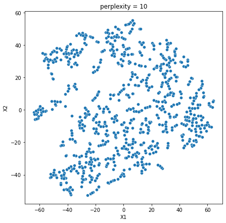

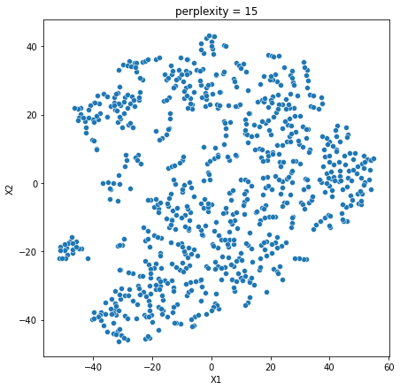

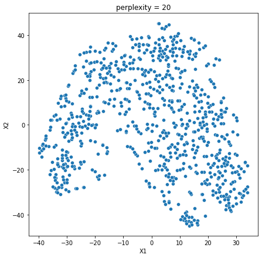

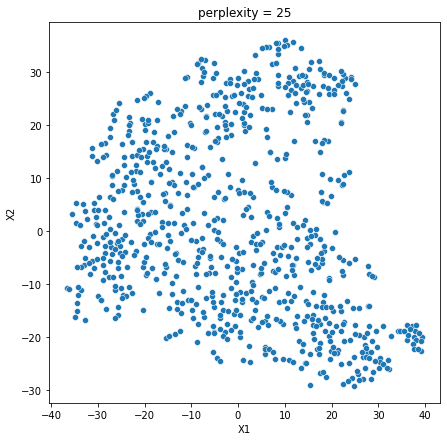

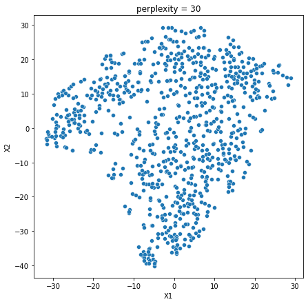

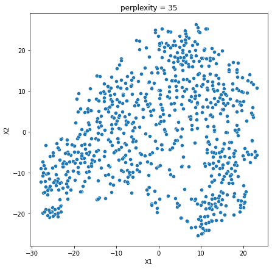

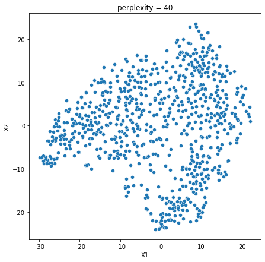

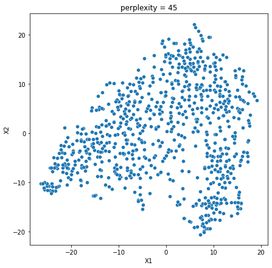

```python
for i in range(10, 50, 5):
    tsne = TSNE(n_components = 2, random_state = 1, perplexity = i)

    data_tsne = tsne.fit_transform(data_scaled)

    data_tsne = pd.DataFrame(data_tsne)

    data_tsne.columns = ['X1', 'X2']

    plt.figure(figsize = (7, 7))

    sns.scatterplot(x = 'X1', y = 'X2', data = data_tsne)

    plt.title("perplexity = {}".format(i))
```

#### Observations

1. All the plots with different perplexity values imply that there is no underlying pattern in the data.
2. It shows that observing patterns in data projection and visualization techniques like PCA and SNE, is actually dependent on the nature of the data.